# 03

Rani Yasmin Azzahra

2023-09-16

## Packages

```r
library(dLagM)
library(dynlm)
library(MLmetrics)
library(lmtest)
library(car)
```

## Input data

```r
df <- rio::import("https://raw.githubusercontent.com/raniysmnz/MPDW/main/Pertemuan%203/wine_fixed.csv")
data <- df[14:33,]
str(data)
```

```
## 'data.frame':    20 obs. of  4 variables:
##  $ t     : int  2001 2002 2003 2004 2005 2006 2007 2008 2009 2010 ...
##  $ xt    : int  3570 4060 3953 4209 4642 5720 5029 4182 5165 4670 ...
##  $ yt    : num  1209 1153 1121 1095 1064 ...
##  $ y(t-1): num  1194 1209 1153 1121 1095 ...
```

## Pembagian data

```r
#data train dan test
train <- data[1:15,]
test <- data[16:20,]
```

```r
#data time series
train.ts <- ts(train)
test.ts<-ts(test)
data.ts<-ts(data)
```

## Model Koyck

Model Koyck didasarkan pada asumsi bahwa semakin jauh jarak lag peubah independen dari periode sekarang maka semakin kecil pengaruh peubah lag terhadap peubah dependen.

Koyck mengusulkan suatu metode untuk menduga model dinamis distributed lag dengan mengasumsikan bahwa semua koefisien $\beta$ mempunyai tanda sama.

Model kyock merupakan jenis paling umum dari model infinite distributed lag dan juga dikenal sebagai geometric lag

$$y_t=a(1-\lambda)+\beta_0X_t+\beta_1Z_t+\lambda Y_{t-1}+V_t$$
dengan
$$V_t=u_t-\lambda
u_{t-1}$$

### Pemodelan

Pemodelan model Koyck dengan `R` dapat menggunakan `dLagM::koyckDlm()` . Fungsi umum dari `koyckDlm` adalah sebagai berikut.

```r
# koyckDlm(x , y , intercept)
```

Fungsi `koyckDlm()` akan menerapkan model lag terdistribusi dengan transformasi Koyck satu prediktor. Nilai `x` dan `y` tidak perlu sebagai objek *time series* (`ts`). `intercept` dapat dibuat `TRUE` untuk memasukkan intersep ke dalam model.

```r
#MODEL KOYCK
model.koyck <- koyckDlm(x = train$xt, y = train$yt)
summary(model.koyck)
```

```
##
## Call:
## "Y ~ (Intercept) + Y.1 + X.t"
##
## Residuals:
##     Min      1Q  Median      3Q     Max
## -177.68  -65.45   24.42   58.43  165.89
##
## Coefficients:
##              Estimate Std. Error t value Pr(>|t|)
## (Intercept) -261.3886   407.8222  -0.641    0.535
## Y.1            0.6417     0.3898   1.646    0.128
## X.t            0.1465     0.1319   1.111    0.290
##
## Residual standard error: 110.3 on 11 degrees of freedom
## Multiple R-Squared: 0.5387,  Adjusted R-squared: 0.4548
## Wald test: 8.448 on 2 and 11 DF,  p-value: 0.005986
##
## Diagnostic tests:
## NULL
##
##                              alpha      beta       phi
## Geometric coefficients:  -729.4652 0.1464627 0.6416708
```

```r
AIC(model.koyck)
```

```
## [1] 176.0357
```

```r
BIC(model.koyck)
```

```
## [1] 178.5919
```

### Peramalan dan Akurasi

Berikut adalah hasil peramalan y untuk 5 periode kedepan menggunakan model koyck

```r
fore.koyck <- forecast(model = model.koyck, x=test$xt, h=5)
fore.koyck
```

```
## $forecasts
## [1] 1589.543 1627.099 1785.943 1912.767 1879.906
##
## $call
## forecast.koyckDlm(model = model.koyck, x = test$xt, h = 5)
##
## attr(,"class")
## [1] "forecast.koyckDlm" "dLagM"
```

```r
mape.koyck <- MAPE(fore.koyck$forecasts, test$yt)
#akurasi data training
GoF(model.koyck)
```

```
##              n      MAE          MPE       MAPE      sMAPE     MASE      MSE
## model.koyck 14 80.78515 -0.003454033 0.06869897 0.06809978 1.122652 9553.569
##                 MRAE    GMRAE
## model.koyck 2.032894 1.098491
```

## Regression with Distributed Lag

Pemodelan model Regression with Distributed Lag dengan `R` dapat menggunakan `dLagM::dlm()` . Fungsi umum dari `dlm` adalah sebagai berikut.

```r
# dlm(formula , data , x , y , q , remove )
```

Fungsi `dlm()` akan menerapkan model lag terdistribusi dengan satu atau lebih prediktor. Nilai `x` dan `y` tidak perlu sebagai objek *time series* (`ts`). $q$ adalah integer yang mewakili panjang *lag* yang terbatas.

### Pemodelan (Lag=2)

```r
model.dlm <- dlm(x = train$xt,y = train$yt , q = 2)
summary(model.dlm)
```

```
##
## Call:
## lm(formula = model.formula, data = design)
##
## Residuals:
##     Min      1Q  Median      3Q     Max
## -151.09  -66.23  -11.39  112.24  129.34
##
## Coefficients:
##              Estimate Std. Error t value Pr(>|t|)
## (Intercept) 111.38676  310.92594   0.358   0.7284
## x.t           0.08451    0.05550   1.523   0.1622
## x.1           0.03951    0.05957   0.663   0.5238
## x.2           0.10797    0.05047   2.139   0.0611 .
## ---
## Signif. codes:  0 '***' 0.001 '**' 0.01 '*' 0.05 '.' 0.1 ' ' 1
##
## Residual standard error: 111.8 on 9 degrees of freedom
## Multiple R-squared:  0.6057, Adjusted R-squared:  0.4742
## F-statistic: 4.608 on 3 and 9 DF,  p-value: 0.0323
##
## AIC and BIC values for the model:
##        AIC     BIC
## 1 164.7503 167.575
```

```r
AIC(model.dlm)
```

```
## [1] 164.7503
```

```r
BIC(model.dlm)
```

```
## [1] 167.575
```

### Peramalan dan Akurasi

Berikut merupakan hasil peramalan $y$ untuk 5 periode kedepan

```r
fore.dlm <- forecast(model = model.dlm, x=test$xt, h=5)
fore.dlm
```

```
## $forecasts
## [1] 1409.724 1430.590 1575.649 1615.569 1655.701
##
## $call
## forecast.dlm(model = model.dlm, x = test$xt, h = 5)
##
## attr(,"class")
## [1] "forecast.dlm" "dLagM"
```

```r
mape.dlm <- MAPE(fore.dlm$forecasts, test$yt)
#akurasi data training
GoF(model.dlm)
```

```
##            n      MAE          MPE       MAPE      sMAPE     MASE      MSE
## model.dlm 13 80.19697 -0.005524308 0.06668913 0.06635928 1.065575 8655.843
##               MRAE    GMRAE
## model.dlm 1.995689 1.037806
```

### *Lag* Optimum

```r
#penentuan lag optimum
finiteDLMauto(formula = yt ~ xt,
              data = data.frame(train), q.min = 1, q.max = 6,
              model.type = "dlm", error.type = "AIC", trace = FALSE)
```

```
##   q - k    MASE      AIC      BIC   GMRAE    MBRAE R.Adj.Sq   Ljung-Box
## 6     6 0.08795 81.43745 83.21247 0.11738 -0.03294  0.97325 0.001114349
```

Berdasarkan output tersebut, lag optimum didapatkan ketika lag=6. Selanjutnya dilakukan pemodelan untuk lag=6

```r
#model dlm dengan lag optimum
model.dlm2 <- dlm(x = train$xt,y = train$yt , q = 6)
summary(model.dlm2)
```

```
##
## Call:
## lm(formula = model.formula, data = design)
##
## Residuals:
##       1       2       3       4       5       6       7       8       9
##   3.622  -6.334   6.056 -10.371  11.560  -9.682   8.363  -8.912   5.697
##
## Coefficients:
##               Estimate Std. Error t value Pr(>|t|)
## (Intercept) -6.537e+02  2.220e+02  -2.945   0.2084
## x.t          1.213e-01  2.584e-02   4.692   0.1337
## x.1          7.028e-02  2.472e-02   2.843   0.2153
## x.2          1.532e-01  2.383e-02   6.427   0.0983 .
## x.3         -4.734e-02  2.747e-02  -1.723   0.3348
## x.4         -5.345e-03  2.496e-02  -0.214   0.8657
## x.5         -3.559e-02  2.578e-02  -1.381   0.3990
## x.6          1.371e-01  1.886e-02   7.272   0.0870 .
## ---
## Signif. codes:  0 '***' 0.001 '**' 0.01 '*' 0.05 '.' 0.1 ' ' 1
##
## Residual standard error: 24.63 on 1 degrees of freedom
## Multiple R-squared:  0.9967, Adjusted R-squared:  0.9733
## F-statistic: 42.59 on 7 and 1 DF,  p-value: 0.1175
##
## AIC and BIC values for the model:
##        AIC      BIC
## 1 81.43745 83.21247
```

```r
AIC(model.dlm2)
```

```
## [1] 81.43745
```

```r
BIC(model.dlm2)
```

```
## [1] 83.21247
```

Adapun hasil peramalan 5 periode kedepan menggunakan model tersebut adalah sebagai berikut

```r
#peramalan dan akurasi
fore.dlm2 <- forecast(model = model.dlm2, x=test$xt, h=5)
mape.dlm2<- MAPE(fore.dlm2$forecasts, test$yt)
#akurasi data training
GoF(model.dlm2)
```

```
##            n      MAE          MPE        MAPE       sMAPE       MASE      MSE
## model.dlm2 9 7.844015 -5.90371e-05 0.006218646 0.006216942 0.08794848 67.40565
##                 MRAE     GMRAE
## model.dlm2 0.1677376 0.1173765
```

Model tersebut merupakan model yang sangat baik dengan nilai MAPE yang kurang dari 10%.

## Model Autoregressive

Peubah dependen dipengaruhi oleh peubah independen pada waktu sekarang, serta dipengaruhi juga oleh peubah dependen itu sendiri pada satu waktu yang lalu maka model tersebut disebut *autoregressive* (Gujarati 2004).

### Pemodelan

Pemodelan Autoregressive dilakukan menggunakan fungsi `dLagM::ardlDlm()` . Fungsi tersebut akan menerapkan *autoregressive* berordo $(p,q)$ dengan satu prediktor. Fungsi umum dari `ardlDlm()` adalah sebagai berikut.

```r
# ardlDlm(formula = NULL , data = NULL , x = NULL , y = NULL , p = 1 , q = 1 ,
         remove = NULL )
```

Dengan $p$ adalah integer yang mewakili panjang *lag* yang terbatas dan $q$ adalah integer yang merepresentasikan ordo dari proses *autoregressive*.

```r
model.ardl <- ardlDlm(x = train$xt, y = train$yt, p = 1 , q = 1)
summary(model.ardl)
```

```
##
## Time series regression with "ts" data:
## Start = 2, End = 15
##
## Call:
## dynlm(formula = as.formula(model.text), data = data, start = 1)
##
## Residuals:
##      Min       1Q   Median       3Q      Max
## -135.346  -41.313   -9.083   35.903  150.694
##
## Coefficients:
##              Estimate Std. Error t value Pr(>|t|)
## (Intercept) -88.46896  261.41294  -0.338  0.74204
## X.t           0.02927    0.04609   0.635  0.53964
## X.1           0.04158    0.04159   1.000  0.34103
## Y.1           0.80862    0.23167   3.490  0.00582 **
## ---
## Signif. codes:  0 '***' 0.001 '**' 0.01 '*' 0.05 '.' 0.1 ' ' 1
##
## Residual standard error: 90.13 on 10 degrees of freedom
## Multiple R-squared:  0.7198, Adjusted R-squared:  0.6358
## F-statistic: 8.565 on 3 and 10 DF,  p-value: 0.004089
```

```r
AIC(model.ardl)
```

```
## [1] 171.0542
```

```r
BIC(model.ardl)
```

```
## [1] 174.2495
```

### Peramalan dan Akurasi

```r
fore.ardl <- forecast(model = model.ardl, x=test$xt, h=5)
fore.ardl
```

```
## $forecasts
## [1] 1530.865 1573.714 1631.135 1720.794 1777.532
##
## $call
## forecast.ardlDlm(model = model.ardl, x = test$xt, h = 5)
##
## attr(,"class")
## [1] "forecast.ardlDlm" "dLagM"
```

Data di atas merupakan hasil peramalan untuk 5 periode ke depan menggunakan Model Autoregressive dengan $p=1$ dan $q=1$.

```r
mape.ardl <- MAPE(fore.ardl$forecasts, test$yt)
mape.ardl
```

```
## [1] 0.05044352
```

```r
#akurasi data training
GoF(model.ardl)
```

```
##             n     MAE          MPE       MAPE      sMAPE      MASE      MSE
## model.ardl 14 58.4709 -0.003949683 0.04844955 0.04839837 0.8125559 5802.197
##                MRAE     GMRAE
## model.ardl 1.041799 0.8122718
```

Berdasarkan akurasi di atas, terlihat bahwa nilai MAPE keduanya tidak jauh berbeda. Artinya, model regresi dengan distribusi lag ini tidak `overfitted` atau `underfitted`

### *Lag* Optimum

```r
#penentuan lag optimum
model.ardl.opt <- ardlBoundOrders(data = data.frame(data), ic = "AIC",
                                  formula = yt ~ xt )
min_p=c()
for(i in 1:6){
  min_p[i]=min(model.ardl.opt$Stat.table[[i]])
}
q_opt=which(min_p==min(min_p, na.rm = TRUE))
p_opt=which(model.ardl.opt$Stat.table[[q_opt]] ==
              min(model.ardl.opt$Stat.table[[q_opt]], na.rm = TRUE))
data.frame("q_optimum" = q_opt, "p_optimum" = p_opt,
           "AIC"=model.ardl.opt$min.Stat)
```

```
##   q_optimum p_optimum      AIC
## 1         1         6 138.9842
```

Selanjutnya dapat dilakukan pemodelan dengan nilai $p$ dan $q$ optimum seperti inisialisasi di langkah sebelumnya.

## Pemodelan DLM & ARDL dengan Library `dynlm`

Pemodelan regresi dengan peubah *lag* tidak hanya dapat dilakukan dengan fungsi pada *packages* `dLagM` , tetapi terdapat *packages* `dynlm` yang dapat digunakan. Fungsi `dynlm` secara umum adalah sebagai berikut.

```r
# dynlm(formula, data, subset, weights, na.action, method = "qr",
  model = TRUE, x = FALSE, y = FALSE, qr = TRUE, singular.ok = TRUE,
  contrasts = NULL, offset, start = NULL, end = NULL, ...)
```

Untuk menentukan `formula` model yang akan digunakan, tersedia fungsi tambahan yang memungkinkan spesifikasi dinamika (melalui `d()` dan `L()`) atau pola linier/siklus dengan mudah (melalui `trend()`, `season()`, dan `harmon()`). Semua fungsi formula baru mengharuskan argumennya berupa objek deret waktu (yaitu, `"ts"` atau `"zoo"`).

```r
#sama dengan model dlm q=1
cons_lm1 <- dynlm(yt ~ xt+L(xt),data = train.ts)
#sama dengan model ardl p=1 q=0
cons_lm2 <- dynlm(yt ~ xt+L(yt),data = train.ts)
#sama dengan ardl p=1 q=1
cons_lm3 <- dynlm(yt ~ xt+L(xt)+L(yt),data = train.ts)
#sama dengan dlm p=2
cons_lm4 <- dynlm(yt ~ xt+L(xt)+L(xt,2),data = train.ts)
```

### Ringkasan Model

```r
summary(cons_lm1)
```

```
##
## Time series regression with "ts" data:
## Start = 2, End = 15
##
## Call:
## dynlm(formula = yt ~ xt + L(xt), data = train.ts)
##
## Residuals:
##     Min      1Q  Median      3Q     Max
## -194.22  -87.09   28.39   79.25  203.46
##
## Coefficients:
##              Estimate Std. Error t value Pr(>|t|)
## (Intercept) 480.69950  290.15423   1.657    0.126
## xt            0.07487    0.06277   1.193    0.258
## L(xt)         0.07903    0.05706   1.385    0.194
##
## Residual standard error: 128 on 11 degrees of freedom
## Multiple R-squared:  0.3785, Adjusted R-squared:  0.2655
## F-statistic:  3.35 on 2 and 11 DF,  p-value: 0.07308
```

```r
summary(cons_lm2)
```

```
##
## Time series regression with "ts" data:
## Start = 2, End = 15
##
## Call:
## dynlm(formula = yt ~ xt + L(yt), data = train.ts)
##
## Residuals:
##     Min      1Q  Median      3Q     Max
## -139.74  -50.86  -19.39   69.33  141.07
##
## Coefficients:
##              Estimate Std. Error t value Pr(>|t|)
## (Intercept) -51.31799  258.75088  -0.198  0.84640
## xt            0.04739    0.04238   1.118  0.28731
## L(yt)         0.86837    0.22382   3.880  0.00256 **
## ---
## Signif. codes:  0 '***' 0.001 '**' 0.01 '*' 0.05 '.' 0.1 ' ' 1
##
## Residual standard error: 90.13 on 11 degrees of freedom
## Multiple R-squared:  0.6918, Adjusted R-squared:  0.6358
## F-statistic: 12.35 on 2 and 11 DF,  p-value: 0.001542
```

```r
summary(cons_lm3)
```

```
##
## Time series regression with "ts" data:
## Start = 2, End = 15
##
## Call:
## dynlm(formula = yt ~ xt + L(xt) + L(yt), data = train.ts)
##
## Residuals:
##      Min       1Q   Median       3Q      Max
## -135.346  -41.313   -9.083   35.903  150.694
##
## Coefficients:
##              Estimate Std. Error t value Pr(>|t|)
## (Intercept) -88.46896  261.41294  -0.338  0.74204
## xt            0.02927    0.04609   0.635  0.53964
## L(xt)         0.04158    0.04159   1.000  0.34103
## L(yt)         0.80862    0.23167   3.490  0.00582 **
## ---
## Signif. codes:  0 '***' 0.001 '**' 0.01 '*' 0.05 '.' 0.1 ' ' 1
##
## Residual standard error: 90.13 on 10 degrees of freedom
## Multiple R-squared:  0.7198, Adjusted R-squared:  0.6358
## F-statistic: 8.565 on 3 and 10 DF,  p-value: 0.004089
```

```r
summary(cons_lm4)
```

```
##
## Time series regression with "ts" data:
## Start = 3, End = 15
##
## Call:
## dynlm(formula = yt ~ xt + L(xt) + L(xt, 2), data = train.ts)
##
## Residuals:
##     Min      1Q  Median      3Q     Max
## -151.09  -66.23  -11.39  112.24  129.34
##
## Coefficients:
##              Estimate Std. Error t value Pr(>|t|)
## (Intercept) 111.38676  310.92594   0.358   0.7284
## xt            0.08451    0.05550   1.523   0.1622
## L(xt)         0.03951    0.05957   0.663   0.5238
## L(xt, 2)      0.10797    0.05047   2.139   0.0611 .
## ---
## Signif. codes:  0 '***' 0.001 '**' 0.01 '*' 0.05 '.' 0.1 ' ' 1
##
## Residual standard error: 111.8 on 9 degrees of freedom
## Multiple R-squared:  0.6057, Adjusted R-squared:  0.4742
## F-statistic: 4.608 on 3 and 9 DF,  p-value: 0.0323
```

```r
deviance(cons_lm1)
```

```
## [1] 180196.8
```

```r
deviance(cons_lm2)
```

```
## [1] 89348.93
```

```r
deviance(cons_lm3)
```

```
## [1] 81230.76
```

```r
deviance(cons_lm4)
```

```
## [1] 112526
```

### Uji Diagnostik

```r
#uji model
if(require("lmtest")) encomptest(cons_lm1, cons_lm2)
```

```
## Encompassing test
##
## Model 1: yt ~ xt + L(xt)
## Model 2: yt ~ xt + L(yt)
## Model E: yt ~ xt + L(xt) + L(yt)
##           Res.Df Df       F   Pr(>F)
## M1 vs. ME     10 -1 12.1833 0.005819 **
## M2 vs. ME     10 -1  0.9994 0.341032
## ---
## Signif. codes:  0 '***' 0.001 '**' 0.01 '*' 0.05 '.' 0.1 ' ' 1
```

#### Autokorelasi

```r
#durbin watson
dwtest(cons_lm1)
```

```
##
##  Durbin-Watson test
##
## data:  cons_lm1
## DW = 0.97112, p-value = 0.01131
## alternative hypothesis: true autocorrelation is greater than 0
```

```r
dwtest(cons_lm2)
```

```
##
##  Durbin-Watson test
##
## data:  cons_lm2
## DW = 1.6762, p-value = 0.1482
## alternative hypothesis: true autocorrelation is greater than 0
```

```r
dwtest(cons_lm3)
```

```
##
##  Durbin-Watson test
##
## data:  cons_lm3
## DW = 1.7184, p-value = 0.1698
## alternative hypothesis: true autocorrelation is greater than 0
```

```r
dwtest(cons_lm4)
```

```
##
##  Durbin-Watson test
##
## data:  cons_lm4
## DW = 0.78, p-value = 0.005368
## alternative hypothesis: true autocorrelation is greater than 0
```

#### Heterogenitas

```r
bptest(cons_lm1)
```

```
##
##  studentized Breusch-Pagan test
##
## data:  cons_lm1
## BP = 3.0222, df = 2, p-value = 0.2207
```

```r
bptest(cons_lm2)
```

```
##
##  studentized Breusch-Pagan test
##
## data:  cons_lm2
## BP = 1.4356, df = 2, p-value = 0.4878
```

```r
bptest(cons_lm3)
```

```
##
##  studentized Breusch-Pagan test
##
## data:  cons_lm3
## BP = 1.9242, df = 3, p-value = 0.5883
```

```r
bptest(cons_lm4)
```

```
##
##  studentized Breusch-Pagan test
##
## data:  cons_lm4
## BP = 5.8208, df = 3, p-value = 0.1207
```

#### Kenormalan

```r
shapiro.test(residuals(cons_lm1))
```

```
##
##  Shapiro-Wilk normality test
##
## data:  residuals(cons_lm1)
## W = 0.96409, p-value = 0.7894
```

```r
shapiro.test(residuals(cons_lm2))
```

```
##
##  Shapiro-Wilk normality test
##
## data:  residuals(cons_lm2)
## W = 0.96504, p-value = 0.8043
```

```r
shapiro.test(residuals(cons_lm3))
```

```
##
##  Shapiro-Wilk normality test
##
## data:  residuals(cons_lm3)
## W = 0.96631, p-value = 0.8238
```

```r
shapiro.test(residuals(cons_lm4))
```

```
##
##  Shapiro-Wilk normality test
##
## data:  residuals(cons_lm4)
## W = 0.92229, p-value = 0.2693
```

```r
akurasi <- matrix(c(mape.koyck, mape.dlm, mape.dlm2, mape.ardl))
row.names(akurasi)<- c("Koyck","DLM 1","DLM 2","Autoregressive")
colnames(akurasi) <- c("MAPE")
akurasi
```

```
##                      MAPE
## Koyck          0.11974438
## DLM 1          0.04814473
## DLM 2          0.09443958
## Autoregressive 0.05044352
```

### Plot

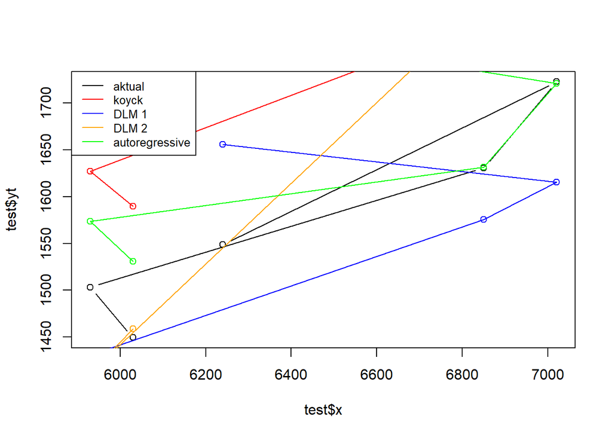

```r
par(mfrow=c(1,1))
plot(test$x, test$yt, type="b", col="black", main=(""))
points(test$xt, fore.koyck$forecasts,col="red")
lines(test$xt, fore.koyck$forecasts,col="red")
points(test$xt, fore.dlm$forecasts,col="blue")
lines(test$xt, fore.dlm$forecasts,col="blue")
points(test$xt, fore.dlm2$forecasts,col="orange")
lines(test$xt, fore.dlm2$forecasts,col="orange")
points(test$xt, fore.ardl$forecasts,col="green")
lines(test$xt, fore.ardl$forecasts,col="green")
legend("topleft",c("aktual", "koyck","DLM 1","DLM 2", "autoregressive"), lty=1, col=c("black","red","blue","orange","green"), cex=0.8)
```

Berdasarkan plot dan data MAPE tiap pemodelan tersebut, terlihat bahwa plot yang paling mendekati data aktualnya adalah Model DLM 1, sehingga dapat disimpulkan model terbaik dalam hal ini adalah model DLM 1